# BSF 3 Stage Gene Expression Overview and VST-count Generation

Erin Chille

Last updated 2021/06/21

## Set up workspace

Import necessary libraries

```r
library("tidyverse")
library("genefilter")
library("DESeq2")
library("RColorBrewer")
library("pheatmap")
```

## Stylophora pistillata

### Data input, cleaning, and pre-processing

Import the data files

```r
treatmentinfo <- read.csv("Spistillata/5-Spis-SampleInfo.csv", header = TRUE, sep = ",")
head(treatmentinfo)
```

```
##      sampleID timepoint
## 1 SRR14333319       III
## 2 SRR14333320       III
## 3 SRR14333321       III
## 4 SRR14333322        II
## 5 SRR14333323        II
## 6 SRR14333324        II
```

```r
gcount <- as.data.frame(read.csv("Spistillata/4-Spis-GeneCountMatrix.csv", row.names="gene_id"), colClasses = double)
head(gcount)
```

```
##              SRR14333319 SRR14333320 SRR14333321 SRR14333322 SRR14333323
## SpisGene3669           0           0           0           0           0
## SpisGene3668         229         186         230          20         106
## SpisGene3666        2910        2511        2477        6818        3977
## SpisGene3665         881         913         877         465         833
## SpisGene3664        1223        1242        1628        4241        1489
## SpisGene3663          26          48          53          25          20
##              SRR14333324 SRR14333325 SRR14333326 SRR14333327
## SpisGene3669           0           0           0           0
## SpisGene3668          88          15          14          17
## SpisGene3666        4747        4640        3838        4905
## SpisGene3665        1322         466         425         393
## SpisGene3664         993         726         945         715
## SpisGene3663          58          10           0          11
```

```r
dim(gcount)
```

```
## [1] 25769     9
```

#### Quality-filter gene counts

Pre-filtering our dataset to reduce the memory size dataframe, increases the speed of the transformation and testing functions, and improves the quality of statistical analysis by removing low-coverage counts. Removed counts could represent outliers in the data and removing these improves sensitivity of statistical tests. Here we will filter out the genes that are only present in fewer than two of the 9 samples. This means that two or more samples have to have an abundance of 10 or greater in order to be kept for further analysis.

```r
dim(treatmentinfo) #rows should be 9
```

```
## [1] 9 2
```

```r
#create filter for the counts data
#gfiltdev <- rowSums(count(gcount)) > 0
#set filter values for PoverA, P=100% percent of the samples have counts over A=10. This means that only 2 out of 9 (0.22) samples need to have counts over 10. Our smallest sample size for our life stages is two (fertilized egg, mid-gastrula, early-gastrula). By setting 2/9 as the P, this means if a particular gene is expressed only in 1 of these smallest life stages, it will be included in the analysis.
filt <- filterfun(pOverA(0.22,10))

#create filter for the counts data
gfiltdev <- genefilter(gcount, filt)

#identify genes to keep by count filter
gkeepdev <- gcount[gfiltdev,]

#identify genes to keep by count filter
gkeepdev <- gcount[gfiltdev,]

#identify gene lists
gn.keepdev <- rownames(gkeepdev)

#gene count data filtered in PoverA, P percent of the samples have counts over A
gcount_filt <- as.data.frame(gcount[which(rownames(gcount) %in% gn.keepdev),])

#How many rows do we have before and after filtering?
nrow(gcount) #Before
```

```
## [1] 25769
```

```r
nrow(gcount_filt) #After
```

```
## [1] 16907
```

### Quality-check of datasets

In order for the DESeq2 algorithms to work, the SampleIDs on the treatmentinfo file and count matrices have to match exactly and in the same order. The following R clump will check to make sure that these match.

```r
#Checking that all row and column names match. Should return "TRUE"
treatmentinfo$sampleID == colnames(gcount_filt)
```

```
## [1] TRUE TRUE TRUE TRUE TRUE TRUE TRUE TRUE TRUE
```

### Read normalization

We are now going normalize our read counts using VST-normalization in DESeq2

#### Construct the DESeq2 dataset

Merge the treatment and time_point columns into a new column , group. Set group as a factor.

```r
treatmentinfo$timepoint <- factor(treatmentinfo$timepoint, levels = c("I", "II", "III"))
str(treatmentinfo)
```

```
## 'data.frame':    9 obs. of  2 variables:
##  $ sampleID : chr  "SRR14333319" "SRR14333320" "SRR14333321" "SRR14333322" ...
##  $ timepoint: Factor w/ 3 levels "I","II","III": 3 3 3 2 2 2 1 1 1
```

Create a DESeqDataSet design from gene count matrix and labels. Here we set the design to look at time_point to test for any differences in gene expression across timepoints.

```r
#Set DESeq2 design
gdds <- DESeqDataSetFromMatrix(countData = gcount_filt,
                              colData = treatmentinfo,
                              design = ~timepoint)
```

#### Log-transform the count data

First we are going to log-transform the data using a variance stabilizing transforamtion (VST). This is only for visualization purposes. Essentially, this is roughly similar to putting the data on the log2 scale. It will deal with the sampling variability of low counts by calculating within-group variability (if blind=FALSE). Importantly, it does not use the design to remove variation in the data, and so can be used to examine if there may be any variability do to technical factors such as extraction batch effects.

To do this we first need to calculate the size factors of our samples. This is a rough estimate of how many reads each sample contains compared to the others. In order to use VST (the faster log2 transforming process) to log-transform our data, the size factors need to be less than 4. Otherwise, there could be artefacts in our results.

```r
SF.gdds <- estimateSizeFactors(gdds) #estimate size factors to determine if we can use vst  to transform our data. Size factors should be less than for to use vst
print(sizeFactors(SF.gdds)) #View size factors
```

```
## SRR14333319 SRR14333320 SRR14333321 SRR14333322 SRR14333323 SRR14333324
##   1.4877343   1.4309200   1.4121750   0.7336862   1.1606892   1.5475366
## SRR14333325 SRR14333326 SRR14333327
##   0.7817657   0.5253162   0.6940382
```

Our size factors are all less than 4, so we can use VST!

```r
gvst <- vst(gdds, blind=FALSE) #apply a variance stabilizing transforamtion to minimize effects of small counts and normalize wrt library size
head(assay(gvst), 3) #view transformed gene count data
```

```
##              SRR14333319 SRR14333320 SRR14333321 SRR14333322 SRR14333323
## SpisGene3668    7.706490    7.526531    7.768139    6.222825    7.173980
## SpisGene3666   10.976345   10.824535   10.823912   13.191035   11.767065
## SpisGene3665    9.344218    9.442796    9.407001    9.433911    9.599326
##              SRR14333324 SRR14333325 SRR14333326 SRR14333327
## SpisGene3668    6.753502     6.01878    6.208782    6.157476
## SpisGene3666   11.610245    12.54937   12.846488   12.798947
## SpisGene3665    9.833581     9.35289    9.760159    9.285366
```

##### Plot a heatmap of sample-to-sample distances

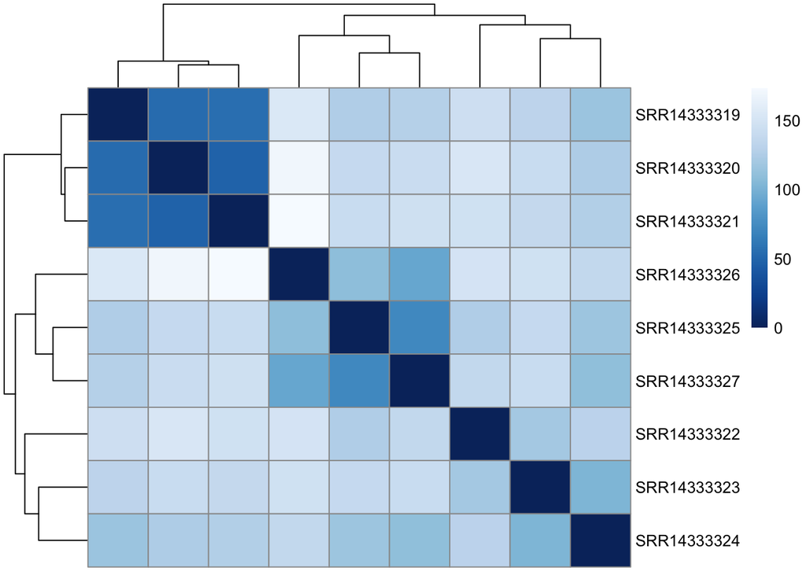

```r
gsampleDists <- dist(t(assay(gvst))) #calculate distance matix
gsampleDistMatrix <- as.matrix(gsampleDists) #distance matrix
rownames(gsampleDistMatrix) <- colnames(gvst) #assign row names
colnames(gsampleDistMatrix) <- NULL #assign col names
colors <- colorRampPalette( rev(brewer.pal(9, "Blues")) )(255) #assign colors
pheatmap(gsampleDistMatrix, #plot matrix
         clustering_distance_rows=gsampleDists, #cluster rows
         clustering_distance_cols=gsampleDists, #cluster columns
         col=colors) #set colors
```

##### Principal component plot of samples

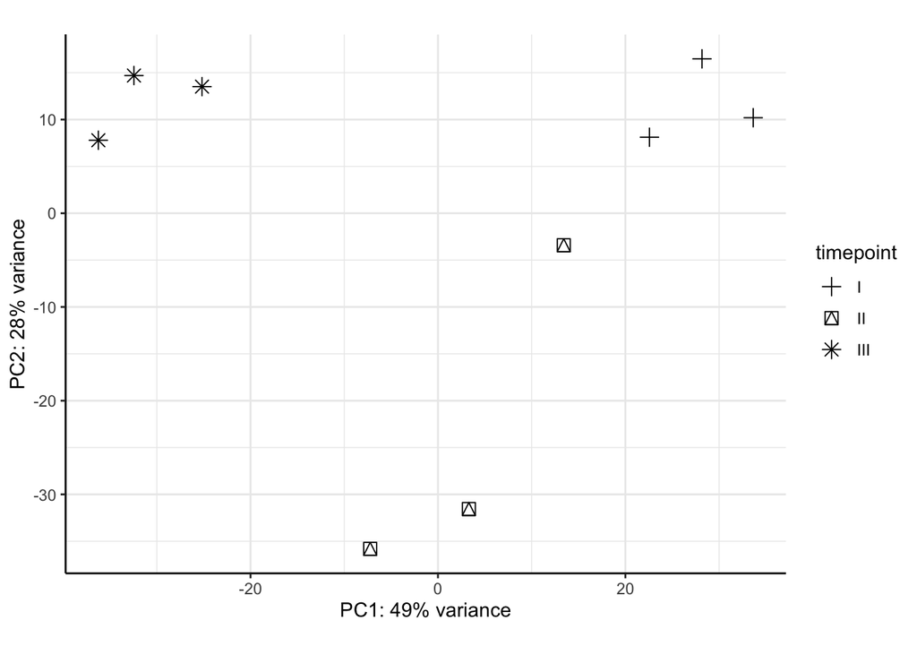

```r
gPCAdata <- plotPCA(gvst, intgroup = c("timepoint"), returnData=TRUE)
percentVar <- round(100*attr(gPCAdata, "percentVar")) #plot PCA of samples with all data

ggplot(gPCAdata, aes(PC1, PC2, shape=timepoint)) +
  geom_point(size=3) +
  xlab(paste0("PC1: ",percentVar[1],"% variance")) +
  ylab(paste0("PC2: ",percentVar[2],"% variance")) +
  scale_shape_manual(values = c("I"=3, "II"=14, "III"=8)) +
  coord_fixed() +
    theme_bw() + #Set background color
  theme(panel.border = element_blank(), # Set border
                     #panel.grid.major = element_blank(), #Set major gridlines
                     #panel.grid.minor = element_blank(), #Set minor gridlines
                     axis.line = element_line(colour = "black"), #Set axes color
        plot.background=element_blank()) # + #Set the plot background
```

```r
  #theme(legend.position = ("none")) #set title attributes
```

Save vst-transformed data as a csv

```r
write.csv(as.data.frame(assay(gvst)), "Spistillata/5-Spis-vst-transformed-genecounts.csv")
```

# Montipora capitata

### Data input, cleaning, and pre-processing

Import the data files

```r
treatmentinfo <- read.csv("Mcapitata/5-Mcap-SampleInfo.csv", header = TRUE, sep = ",")
head(treatmentinfo)
```

```
##   sampleID timepoint
## 1      AH1         I
## 2      AH2         I
## 3      AH3         I
## 4      AH4        II
## 5      AH5        II
## 6      AH6        II
```

```r
gcount <- as.data.frame(read.csv("Mcapitata/4-Mcap-GeneCountMatrix.csv", row.names="gene_id"), colClasses = double)
head(gcount)
```

```
##                    AH1 AH2 AH3 AH4 AH5 AH6 AH7 AH8 AH9
## g16981             201 103 103 171 116 145  79 134 223
## g16980               0   0   0   0   0   0  27   0   0
## g16983               0   5   0   2   0   0   0   0   0
## adi2mcaRNA10886_R1   7  26  12  16  17  16   0  11   9
## g16985               6  12   0   5   1   3   5  13  10
## g16984               8   4   7   8   3   5  21  26  48
```

```r
dim(gcount)
```

```
## [1] 63227     9
```

#### Quality-filter gene counts

Pre-filtering our dataset to reduce the memory size dataframe, increases the speed of the transformation and testing functions, and improves the quality of statistical analysis by removing low-coverage counts. Removed counts could represent outliers in the data and removing these improves sensitivity of statistical tests. Here we will filter out the genes that are only present in fewer than two of the 9 samples. This means that two or more samples have to have an abundance of 10 or greater in order to be kept for further analysis.

```r
dim(treatmentinfo) #rows should be 9
```

```
## [1] 9 2
```

```r
#create filter for the counts data
#gfiltdev <- rowSums(count(gcount)) > 0
#set filter values for PoverA, P=100% percent of the samples have counts over A=10. This means that only 2 out of 9 (0.22) samples need to have counts over 10. Our smallest sample size for our life stages is two (fertilized egg, mid-gastrula, early-gastrula). By setting 2/9 as the P, this means if a particular gene is expressed only in 1 of these smallest life stages, it will be included in the analysis.
filt <- filterfun(pOverA(0.22,10))

#create filter for the counts data
gfiltdev <- genefilter(gcount, filt)

#identify genes to keep by count filter
gkeepdev <- gcount[gfiltdev,]

#identify genes to keep by count filter
gkeepdev <- gcount[gfiltdev,]

#identify gene lists
gn.keepdev <- rownames(gkeepdev)

#gene count data filtered in PoverA, P percent of the samples have counts over A
gcount_filt <- as.data.frame(gcount[which(rownames(gcount) %in% gn.keepdev),])

#How many rows do we have before and after filtering?
nrow(gcount) #Before
```

```
## [1] 63227
```

```r
nrow(gcount_filt) #After
```

```
## [1] 34451
```

### Quality-check of datasets

In order for the DESeq2 algorithms to work, the SampleIDs on the treatmentinfo file and count matrices have to match exactly and in the same order. The following R clump will check to make sure that these match.

```r
#Checking that all row and column names match. Should return "TRUE"
treatmentinfo$sampleID == colnames(gcount_filt)
```

```
## [1] TRUE TRUE TRUE TRUE TRUE TRUE TRUE TRUE TRUE
```

### Read normalization

We are now going normalize our read counts using VST-normalization in DESeq2

#### Construct the DESeq2 dataset

Merge the treatment and time_point columns into a new column , group. Set group as a factor.

```r
treatmentinfo$timepoint <- factor(treatmentinfo$timepoint, levels = c("I", "II", "III"))
str(treatmentinfo)
```

```
## 'data.frame':    9 obs. of  2 variables:
##  $ sampleID : chr  "AH1" "AH2" "AH3" "AH4" ...
##  $ timepoint: Factor w/ 3 levels "I","II","III": 1 1 1 2 2 2 3 3 3
```

Create a DESeqDataSet design from gene count matrix and labels. Here we set the design to look at time_point to test for any differences in gene expression across timepoints.

```r
#Set DESeq2 design
gdds <- DESeqDataSetFromMatrix(countData = gcount_filt,
                              colData = treatmentinfo,
                              design = ~timepoint)
```

#### Log-transform the count data

First we are going to log-transform the data using a variance stabilizing transforamtion (VST). This is only for visualization purposes. Essentially, this is roughly similar to putting the data on the log2 scale. It will deal with the sampling variability of low counts by calculating within-group variability (if blind=FALSE). Importantly, it does not use the design to remove variation in the data, and so can be used to examine if there may be any variability do to technical factors such as extraction batch effects.

To do this we first need to calculate the size factors of our samples. This is a rough estimate of how many reads each sample contains compared to the others. In order to use VST (the faster log2 transforming process) to log-transform our data, the size factors need to be less than 4. Otherwise, there could be artefacts in our results.

```r
SF.gdds <- estimateSizeFactors(gdds) #estimate size factors to determine if we can use vst  to transform our data. Size factors should be less than for to use vst
print(sizeFactors(SF.gdds)) #View size factors
```

```
##       AH1       AH2       AH3       AH4       AH5       AH6       AH7       AH8
## 1.0652304 1.2846660 1.2766025 1.2089603 1.0699063 1.2625857 0.5525292 0.7496323
##       AH9
## 0.9988602
```

Our size factors are all less than 4, so we can use VST!

```r
gvst <- vst(gdds, blind=FALSE) #apply a variance stabilizing transforamtion to minimize effects of small counts and normalize wrt library size
head(assay(gvst), 3) #view transformed gene count data
```

```
##                         AH1      AH2      AH3      AH4      AH5      AH6
## g16981             8.683068 8.145795 8.149092 8.481217 8.314252 8.348877
## adi2mcaRNA10886_R1 7.370785 7.610444 7.433287 7.504219 7.547269 7.494549
## g16985             7.347090 7.432090 7.050196 7.304721 7.171315 7.243224
##                         AH7      AH8      AH9
## g16981             8.488379 8.643477 8.811271
## adi2mcaRNA10886_R1 7.050196 7.528058 7.425308
## g16985             7.426114 7.569261 7.445475
```

##### Plot a heatmap of sample-to-sample distances

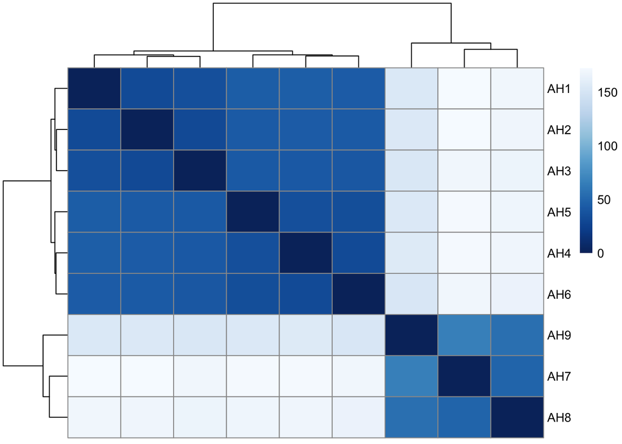

```r
gsampleDists <- dist(t(assay(gvst))) #calculate distance matix
gsampleDistMatrix <- as.matrix(gsampleDists) #distance matrix
rownames(gsampleDistMatrix) <- colnames(gvst) #assign row names
colnames(gsampleDistMatrix) <- NULL #assign col names
colors <- colorRampPalette( rev(brewer.pal(9, "Blues")) )(255) #assign colors
pheatmap(gsampleDistMatrix, #plot matrix
         clustering_distance_rows=gsampleDists, #cluster rows
         clustering_distance_cols=gsampleDists, #cluster columns
         col=colors) #set colors
```

##### Principal component plot of samples

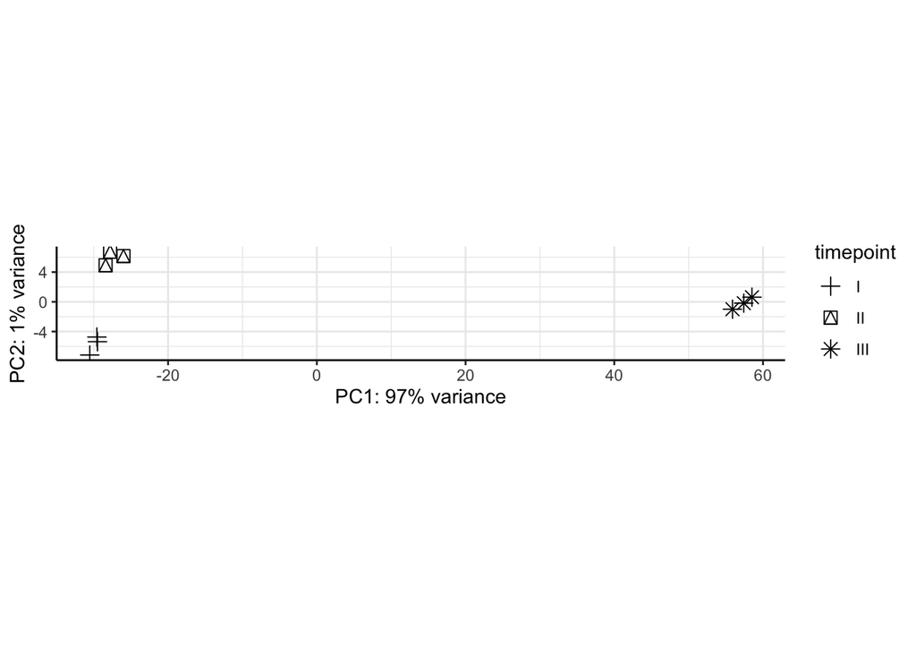

```r
gPCAdata <- plotPCA(gvst, intgroup = c("timepoint"), returnData=TRUE)
percentVar <- round(100*attr(gPCAdata, "percentVar")) #plot PCA of samples with all data

ggplot(gPCAdata, aes(PC1, PC2, shape=timepoint)) +
  geom_point(size=3) +
  xlab(paste0("PC1: ",percentVar[1],"% variance")) +
  ylab(paste0("PC2: ",percentVar[2],"% variance")) +
  scale_shape_manual(values = c("I"=3, "II"=14, "III"=8)) +
  coord_fixed() +
    theme_bw() + #Set background color
  theme(panel.border = element_blank(), # Set border
                     #panel.grid.major = element_blank(), #Set major gridlines
                     #panel.grid.minor = element_blank(), #Set minor gridlines
                     axis.line = element_line(colour = "black"), #Set axes color
        plot.background=element_blank()) # + #Set the plot background
```

```r
  #theme(legend.position = ("none")) #set title attributes
```

Save vst-transformed data as a csv

```r
write.csv(as.data.frame(assay(gvst)), "Mcapitata/5-Mcap-vst-transformed-genecounts.csv")
```

# Pocillopora acuta

### Data input, cleaning, and pre-processing

Import the data files

```r
treatmentinfo <- read.csv("Pacuta/5-Pacu-SampleInfo.csv", header = TRUE, sep = ",")
head(treatmentinfo)
```

```
##     sampleID timepoint
## 1 SRR3051863         I
## 2 SRR3051864         I
## 3 SRR3051865         I
## 4 SRR3051866        II
## 5 SRR3051867        II
## 6 SRR3051868        II
```

```r
gcount <- as.data.frame(read.csv("Pacuta/4-Pacu-GeneCountMatrix.csv", row.names="gene_id"), colClasses = double)
head(gcount)
```

```
##             SRR3051863 SRR3051864 SRR3051865 SRR3051866 SRR3051867 SRR3051868
## XLOC_017763          0          0          0          0          0          0
## XLOC_017762          0          0          0          0          0          0
## XLOC_017761          0          0          1          0          0          0
## XLOC_017760          0          0          1          0          0          0
## XLOC_017767          0          0          0          0          0          0
## XLOC_017766          6          3          7          0          0          0
##             SRR3051869 SRR3051870 SRR3051871
## XLOC_017763          0          0          0
## XLOC_017762          0          0          0
## XLOC_017761          0          1          0
## XLOC_017760          0          0          0
## XLOC_017767          0          0          0
## XLOC_017766          0          4          0
```

```r
dim(gcount)
```

```
## [1] 36140     9
```

#### Quality-filter gene counts

Pre-filtering our dataset to reduce the memory size dataframe, increases the speed of the transformation and testing functions, and improves the quality of statistical analysis by removing low-coverage counts. Removed counts could represent outliers in the data and removing these improves sensitivity of statistical tests. Here we will filter out the genes that are only present in fewer than two of the 9 samples. This means that two or more samples have to have an abundance of 10 or greater in order to be kept for further analysis.

```r
dim(treatmentinfo) #rows should be 9
```

```
## [1] 9 2
```

```r
#create filter for the counts data
#gfiltdev <- rowSums(count(gcount)) > 0
#set filter values for PoverA, P=100% percent of the samples have counts over A=10. This means that only 2 out of 9 (0.22) samples need to have counts over 10. Our smallest sample size for our life stages is two (fertilized egg, mid-gastrula, early-gastrula). By setting 2/9 as the P, this means if a particular gene is expressed only in 1 of these smallest life stages, it will be included in the analysis.
filt <- filterfun(pOverA(0.22,10))

#create filter for the counts data
gfiltdev <- genefilter(gcount, filt)

#identify genes to keep by count filter
gkeepdev <- gcount[gfiltdev,]

#identify genes to keep by count filter
gkeepdev <- gcount[gfiltdev,]

#identify gene lists
gn.keepdev <- rownames(gkeepdev)

#gene count data filtered in PoverA, P percent of the samples have counts over A
gcount_filt <- as.data.frame(gcount[which(rownames(gcount) %in% gn.keepdev),])

#How many rows do we have before and after filtering?
nrow(gcount) #Before
```

```
## [1] 36140
```

```r
nrow(gcount_filt) #After
```

```
## [1] 23717
```

### Quality-check of datasets

In order for the DESeq2 algorithms to work, the SampleIDs on the treatmentinfo file and count matrices have to match exactly and in the same order. The following R clump will check to make sure that these match.

```r
#Checking that all row and column names match. Should return "TRUE"
treatmentinfo$sampleID == colnames(gcount_filt)
```

```
## [1] TRUE TRUE TRUE TRUE TRUE TRUE TRUE TRUE TRUE
```

### Read normalization

We are now going normalize our read counts using VST-normalization in DESeq2

#### Construct the DESeq2 dataset

Merge the treatment and time_point columns into a new column , group. Set group as a factor.

```r
treatmentinfo$timepoint <- factor(treatmentinfo$timepoint, levels = c("I", "II", "III"))
str(treatmentinfo)
```

```
## 'data.frame':    9 obs. of  2 variables:
##  $ sampleID : chr  "SRR3051863" "SRR3051864" "SRR3051865" "SRR3051866" ...
##  $ timepoint: Factor w/ 3 levels "I","II","III": 1 1 1 2 2 2 3 3 3
```

Create a DESeqDataSet design from gene count matrix and labels. Here we set the design to look at time_point to test for any differences in gene expression across timepoints.

```r
#Set DESeq2 design
gdds <- DESeqDataSetFromMatrix(countData = gcount_filt,
                              colData = treatmentinfo,
                              design = ~timepoint)
```

#### Log-transform the count data

First we are going to log-transform the data using a variance stabilizing transforamtion (VST). This is only for visualization purposes. Essentially, this is roughly similar to putting the data on the log2 scale. It will deal with the sampling variability of low counts by calculating within-group variability (if blind=FALSE). Importantly, it does not use the design to remove variation in the data, and so can be used to examine if there may be any variability do to technical factors such as extraction batch effects.

To do this we first need to calculate the size factors of our samples. This is a rough estimate of how many reads each sample contains compared to the others. In order to use VST (the faster log2 transforming process) to log-transform our data, the size factors need to be less than 4. Otherwise, there could be artefacts in our results.

```r
SF.gdds <- estimateSizeFactors(gdds) #estimate size factors to determine if we can use vst  to transform our data. Size factors should be less than for to use vst
print(sizeFactors(SF.gdds)) #View size factors
```

```
## SRR3051863 SRR3051864 SRR3051865 SRR3051866 SRR3051867 SRR3051868 SRR3051869
##  0.9220071  1.2398236  1.2823430  0.8025725  0.7820198  0.9340937  1.0990569
## SRR3051870 SRR3051871
##  1.0526010  1.0739547
```

Our size factors are all less than 4, so we can use VST!

```r
gvst <- vst(gdds, blind=FALSE) #apply a variance stabilizing transforamtion to minimize effects of small counts and normalize wrt library size
head(assay(gvst), 3) #view transformed gene count data
```

```
##             SRR3051863 SRR3051864 SRR3051865 SRR3051866 SRR3051867 SRR3051868
## XLOC_013473  15.489824  15.238138  15.197637  14.166217  14.315192  13.770111
## XLOC_013472   9.377695   9.107020   9.759380   8.629835   8.220637   9.186487
## XLOC_036012   8.943717   9.319613   9.105508   8.409020   8.342149   8.438724
##             SRR3051869 SRR3051870 SRR3051871
## XLOC_013473  14.381668  14.260086  14.359633
## XLOC_013472  12.883379  13.008381  12.854896
## XLOC_036012   9.526844   9.290497   9.596845
```

##### Plot a heatmap of sample-to-sample distances

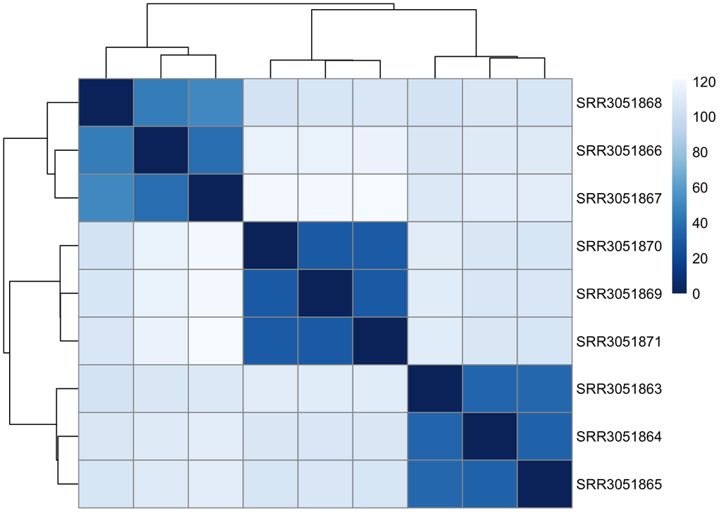

```r
gsampleDists <- dist(t(assay(gvst))) #calculate distance matix
gsampleDistMatrix <- as.matrix(gsampleDists) #distance matrix
rownames(gsampleDistMatrix) <- colnames(gvst) #assign row names
colnames(gsampleDistMatrix) <- NULL #assign col names
colors <- colorRampPalette( rev(brewer.pal(9, "Blues")) )(255) #assign colors
pheatmap(gsampleDistMatrix, #plot matrix
         clustering_distance_rows=gsampleDists, #cluster rows
         clustering_distance_cols=gsampleDists, #cluster columns
         col=colors) #set colors
```

##### Principal component plot of samples

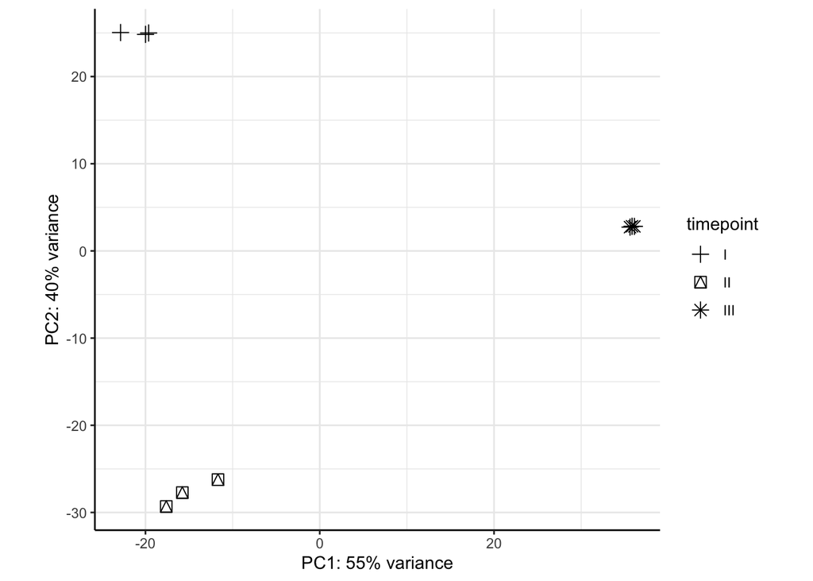

```r
gPCAdata <- plotPCA(gvst, intgroup = c("timepoint"), returnData=TRUE)
percentVar <- round(100*attr(gPCAdata, "percentVar")) #plot PCA of samples with all data

ggplot(gPCAdata, aes(PC1, PC2, shape=timepoint)) +
  geom_point(size=3) +
  xlab(paste0("PC1: ",percentVar[1],"% variance")) +
  ylab(paste0("PC2: ",percentVar[2],"% variance")) +
  scale_shape_manual(values = c("I"=3, "II"=14, "III"=8)) +
  coord_fixed() +
    theme_bw() + #Set background color
  theme(panel.border = element_blank(), # Set border
                     #panel.grid.major = element_blank(), #Set major gridlines
                     #panel.grid.minor = element_blank(), #Set minor gridlines
                     axis.line = element_line(colour = "black"), #Set axes color
        plot.background=element_blank()) # + #Set the plot background
```

```r
  #theme(legend.position = ("none")) #set title attributes
```

Save vst-transformed data as a csv

```r
write.csv(as.data.frame(assay(gvst)), "Pacuta/5-Pacu-vst-transformed-genecounts.csv")
```